# Storm Data Analysis

EzzahraFatmaMHD

2/18/2021

### Impact of Severe **Weather** Events on **Population Health** and **Economic life**.

#### Coursera Reproducible Research - Week 4 - Project 2

# Introduction

This project explores the **NOAA storm database**, which tracks major storms and weather events, to explore the most severe types of weather events in the USA causing the greatest damage to the human life in term of injuries and the economic life during the years 1950 - 2011.

There are two goals of this analysis:

*identify the weather events that are most harmful with respect to population health*  
identify the weather events that have the greatest economic consequences.

# synopsis

The NOAA database tracks characteristics of major storms and weather events in the United States, including when and where they occur, as well as estimates of any fatalities, injuries, and property damage. This project looks at severe weather events can cause both public health and economic problems.

The analysi starts by extracting the needing features from the database : only the variables we need to our analysis. The processing the data to find which events affect more the poeple health and the economy.

# Questions

This data analysis must address the following questions:

1. Across the United States, which types of events (as indicated in the EVTYPE variable) are most harmful with respect to population health?
2. Across the United States, which types of events have the greatest economic consequences?

# Data Analysis

## Data processing

### Preparing work enviroment

```r
library("tidyverse")
library("data.table")
```

```r
library("dplyr")
library("ggplot2")
library("gridExtra")
library("gridtext")
library("grid")
```

### Loading Data

The data for this assignment come in the form of a comma-separated-value file compressed via the bzip2 algorithm to reduce its size. You can download the file from the course web site.

```r
data<- read.csv("D:/data science/02-Data Science Specialization with R (John hopkins uni)/05-Reproductible/week 4 project/repdata_data_StormData.csv.bz2") #load data
dataT <- as.data.table(data) # convert dataframe to datatable
```

### Extracting necessary data

The events in the database start in the year 1950 and end in November 2011.

In the earlier years of the database there are generally fewer events recorded, most likely due to a lack of good records. More recent years should be considered more complete.

```r
#dataT$BGN_DATE <- strptime(dataT$BGN_DATE, "%m/%d/%Y %H:%M:%S")
dataT <- subset(dataT, BGN_DATE > "1995-12-31")
names <- names(dataT)
names
```

```
##  [1] "STATE__"    "BGN_DATE"   "BGN_TIME"   "TIME_ZONE"  "COUNTY"
##  [6] "COUNTYNAME" "STATE"      "EVTYPE"     "BGN_RANGE"  "BGN_AZI"
## [11] "BGN_LOCATI" "END_DATE"   "END_TIME"   "COUNTY_END" "COUNTYENDN"
## [16] "END_RANGE"  "END_AZI"    "END_LOCATI" "LENGTH"     "WIDTH"
## [21] "F"          "MAG"        "FATALITIES" "INJURIES"   "PROPDMG"
## [26] "PROPDMGEXP" "CROPDMG"    "CROPDMGEXP" "WFO"        "STATEOFFIC"
## [31] "ZONENAMES"  "LATITUDE"   "LONGITUDE"  "LATITUDE_E" "LONGITUDE_"
## [36] "REMARKS"    "REFNUM"
```

Based on the documentation and preliminary exploration of the data we can conclude that there are 7 variables we are interested in regarding the two questions.

```r
dataT<- subset(dataT, select = c(EVTYPE, FATALITIES, INJURIES, PROPDMG, PROPDMGEXP,
                                 CROPDMG, CROPDMGEXP))
```

*EVTYPE – type of event*  
FATALITIES – number of fatalities

*INJURIES – number of injuries

*PROPDMG – the size of property damage

*PROPDMGEXP - the exponent values for ‘PROPDMG’ (property damage)

*CROPDMG - the size of crop damage

*CROPDMGEXP - the exponent values for ‘CROPDMG’ (crop damage)

```r
head(unique(dataT$EVTYPE))
```

```
## [1] "TORNADO"               "TSTM WIND"             "HAIL"
## [4] "ICE STORM/FLASH FLOOD" "SNOW/ICE"              "WINTER STORM"
```

# Question 1

**Across the United States, which types of events (as indicated in the EVTYPE variable) are most harmful with respect to population health?**

```r
populationhealth<- aggregate(cbind(FATALITIES,INJURIES)~EVTYPE, data = dataT, sum, na.rm=TRUE)
populationhealth<- arrange(populationhealth, desc(FATALITIES+INJURIES))
head(populationhealth, 10)
```

```
##               EVTYPE FATALITIES INJURIES
## 1            TORNADO       4992    78611
## 2     EXCESSIVE HEAT       1902     6525
## 3          TSTM WIND        471     6257
## 4          LIGHTNING        794     5043
## 5               HEAT        936     2099
## 6        FLASH FLOOD        821     1410
## 7          ICE STORM         27     1657
## 8  THUNDERSTORM WIND        126     1313
## 9               HAIL         14     1344
## 10 HURRICANE/TYPHOON         58      933
```

```r
#Aggregate fatalities ad injuries by Event Type
fatalities <- aggregate(FATALITIES ~ EVTYPE, data=dataT, sum)
injuries <- aggregate(INJURIES ~ EVTYPE, data=dataT, sum)

#Arrange in descending order by Event Type by number of fatalities or injuries
fatalities <- arrange(fatalities,desc(FATALITIES),EVTYPE)[1:10,]
injuries <- arrange(injuries,desc(INJURIES),EVTYPE)[1:10,]

#convert event type variable to factor for analysis
fatalities$EVTYPE <- factor(fatalities$EVTYPE, levels = fatalities$EVTYPE)
injuries$EVTYPE <- factor(injuries$EVTYPE, levels = injuries$EVTYPE)

#Show plot of fatalities by Event Type
fatalitiesbyweather <- ggplot(fatalities, aes(x = EVTYPE, y = FATALITIES)) +
  geom_bar(stat = "identity", fill = "blue", width = NULL) +
  theme(axis.text.x = element_text(angle = 90, hjust = 1)) +
  xlab("Event Type") + ylab("Fatalities")
#Show plot of injuries by Event Type
injuriesbyweather <- ggplot(injuries, aes(x = EVTYPE, y = INJURIES)) +
  geom_bar(stat = "identity", fill = "blue", width = NULL) +
  theme(axis.text.x = element_text(angle = 90, hjust = 1)) +
  xlab("Event Type") + ylab("Injuries")
```

# Question 2

**Across the United States, which types of events have the greatest economic consequences?**

The number/letter in the exponent value columns (PROPDMGEXP and CROPDMGEXP) represents the power of ten (10^The number).

It means that the total size of damage is the product of PROPDMG and CROPDMG and figure 10 in the power corresponding to exponent value.

Exponent values are:

- numbers from one to ten

-letters (B or b = Billion, M or m = Million, K or k = Thousand, H or h = Hundred)

- symbols “-”, “+” and “?” which refers to less than, greater than and low certainty.

```r
dataT$PROPDMGEXP <- gsub("[Hh]", "2", dataT$PROPDMGEXP)
dataT$PROPDMGEXP <- gsub("[Kk]", "3", dataT$PROPDMGEXP)
dataT$PROPDMGEXP <- gsub("[Mm]", "6", dataT$PROPDMGEXP)
dataT$PROPDMGEXPP <- gsub("[Bb]", "9", dataT$PROPDMGEXP)
dataT$PROPDMGEXP <- gsub("\\+", "1", dataT$PROPDMGEXP)
dataT$PROPDMGEXP <- gsub("\\?|\\-|\\ ", "0",  dataT$PROPDMGEXP)
dataT$PROPDMGEXP <- as.numeric(dataT$PROPDMGEXP)
```

```r
dataT$CROPDMGEXP <- gsub("[Hh]", "2", dataT$CROPDMGEXP)
dataT$CROPDMGEXP <- gsub("[Kk]", "3", dataT$CROPDMGEXP)
dataT$CROPDMGEXP <- gsub("[Mm]", "6", dataT$CROPDMGEXP)
dataT$CROPDMGEXP <- gsub("[Bb]", "9", dataT$CROPDMGEXP)
dataT$CROPDMGEXP <- gsub("\\+", "1", dataT$CROPDMGEXP)
dataT$CROPDMGEXP <- gsub("\\-|\\?|\\ ", "0", dataT$CROPDMGEXP)
dataT$CROPDMGEXP <- as.numeric(dataT$CROPDMGEXP)

dataT$PROPDMGEXP[is.na(dataT$PROPDMGEXP)] <- 0
dataT$CROPDMGEXP[is.na(dataT$CROPDMGEXP)] <- 0

dataT<- mutate(dataT,
                    PROPDMGTOTAL = PROPDMG * (10 ^ PROPDMGEXP),
                    CROPDMGTOTAL = CROPDMG * (10 ^ CROPDMGEXP))
Economic_data <- aggregate(cbind(PROPDMGTOTAL, CROPDMGTOTAL) ~ EVTYPE, data = dataT, FUN=sum)
Economic_data$ECONOMIC_LOSS <- Economic_data$PROPDMGTOTAL + Economic_data$CROPDMGTOTAL
Economic_data <- Economic_data[order(Economic_data$ECONOMIC_LOSS, decreasing = TRUE), ]

Top10_events_economy <- Economic_data[1:10,]
#plotting economic loss
g <- ggplot(data = Top10_events_economy, aes(x = reorder(EVTYPE, ECONOMIC_LOSS), y = ECONOMIC_LOSS))
g <- g + geom_bar(stat = "identity", colour = "black")
g <- g + labs(title = "Total economic loss in USA by weather events in 1996-2011")
g <- g + theme(plot.title = element_text(hjust = 0.5))
g <- g + labs(y = "Size of property and crop loss", x = "Event Type")
g <- g + coord_flip()

head(Economic_data, 10)
```

```
##                EVTYPE PROPDMGTOTAL CROPDMGTOTAL ECONOMIC_LOSS
## 633           TORNADO  44871250439    397743070   45268993509
## 125             FLOOD  16332342015   4769447400   21101789415
## 112       FLASH FLOOD  14236758680   1102116600   15338875280
## 185              HAIL  12316813703   2886128873   15202942576
## 66            DROUGHT    918729000   9598943000   10517672000
## 291         HURRICANE   5203178006   2220960000    7424138006
## 297 HURRICANE/TYPHOON   3379640056   2607322800    5986962856
## 304         ICE STORM    733073900   5016225000    5749298900
## 427       RIVER FLOOD     57924005   5028009000    5085933005
## 652         TSTM WIND   4298184010    547427350    4845611360
```

# Results

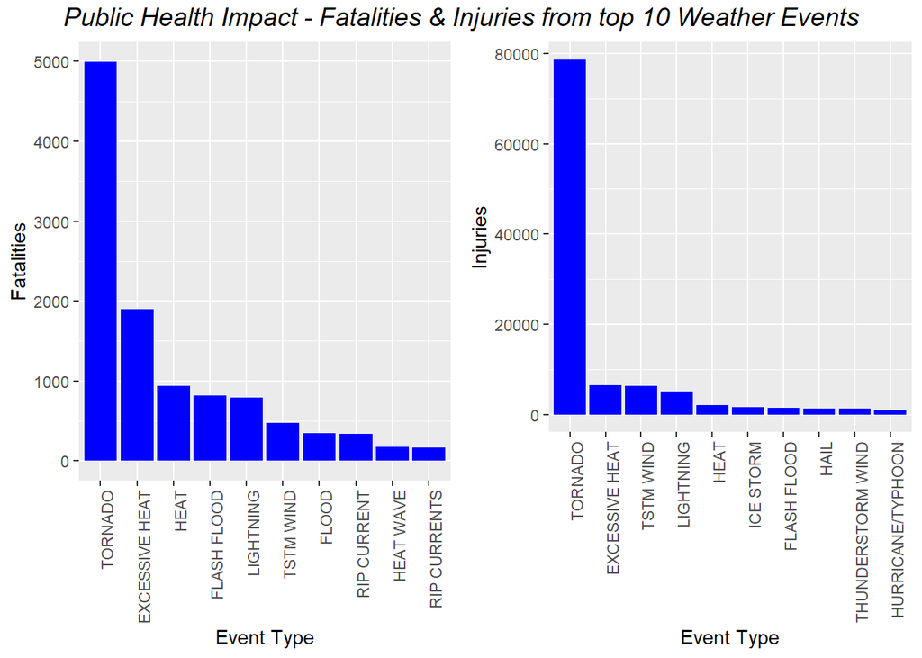

```r
grid.arrange(fatalitiesbyweather, injuriesbyweather, ncol=2, nrow=1,
             top = textGrob("Public Health Impact - Fatalities & Injuries from top 10 Weather Events",gp=gpar(fontsize=14,font=3)))
```

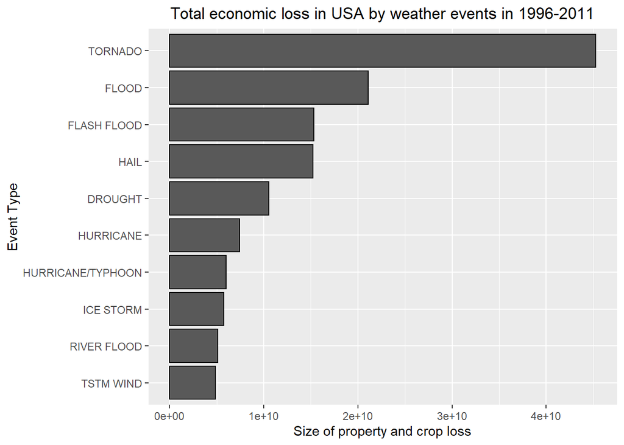

```r
print(g)
```